# Week 8 Model Valuation & Prediction

### Objectives of Regression Models

- Understanding the relationships between predictors and outcomes (Associatiaon and Casual Inference)ex. decision making, social sciences
- Predict values for new data ex. Statistical finance and climate prediction (ML) (out of-sample prediction)

We can use prediction to validate our model - if we see that our model did a great job in predicting new data, then there’s an evidence the model captures the true underlying relationships between the variables.

- Cross-validation - splitting data into two (test & train data) use test data to train the model and train data to predict the values and validate them.

### In-and-Out Sample prediction

- in sample prediction is likely to do well in the model than out of sample prediction

```r
summary(study.skill)
```

```
     Cohort      Interesting         Enjoy          Social.Net      Gender             A.Level
 Min.   :2015   Min.   :0.0000   Min.   :0.0000   Min.   :1.00   Length:47          Min.   :4.000
 1st Qu.:2015   1st Qu.:0.0000   1st Qu.:0.0000   1st Qu.:2.00   Class :character   1st Qu.:6.000
 Median :2015   Median :1.0000   Median :0.0000   Median :3.00   Mode  :character   Median :6.000
 Mean   :2015   Mean   :0.6383   Mean   :0.1915   Mean   :2.66                      Mean   :5.809
 3rd Qu.:2015   3rd Qu.:1.0000   3rd Qu.:0.0000   3rd Qu.:3.00                      3rd Qu.:6.000
 Max.   :2015   Max.   :1.0000   Max.   :1.0000   Max.   :3.00                      Max.   :7.000
  Study.Skills       Grade
 Min.   :12.00   Min.   :38.00
 1st Qu.:22.00   1st Qu.:62.50
 Median :26.00   Median :75.00
 Mean   :25.02   Mean   :70.85
 3rd Qu.:28.50   3rd Qu.:79.00
 Max.   :38.00   Max.   :98.00
```

Regression model prediction allows us to know the interval prediction.

```r
display(lm.3)
```

```
lm(formula = Grade ~ Gender + Interesting + Study.Skills, data = study.skill.train)
             coef.est coef.se
(Intercept)  30.06     8.51
GenderM      -5.70     3.28
Interesting  13.79     3.77
Study.Skills  1.18     0.35
---
n = 86, k = 4
residual sd = 15.03, R-Squared = 0.34
```

More out of sample prediction. - we use 2012, 2013 data to predict data in 2015 - mean square error is an evaluation metric.

Understanding the prediction evaluation through plots. Predicted vs original points plot predicted points vs prediction error

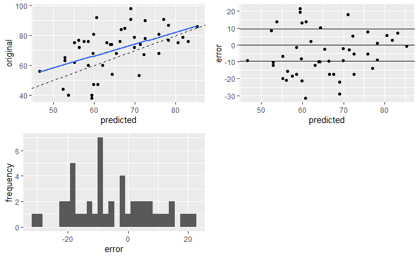

```r
grid.arrange(p1,p2,p3 ,nrow=2, ncol=2)
```

straight line is a desirable line, prediction equal to real true values variability in the y axis and x-axis - yaxis is the grade range, prediction range is usually shorter due to the nature of taking the mean as a prediction. more variability in the y-axis than x-axis indicates the model doest capture the full variablitiy of the model. not a great model - r-square is low. regression is not fit to the data

#### Cross Validation

The smaller the size of a training set the more variable the result is. -smaller sample size

```r
colnames(subset_hourly.pay)
```

```
[1] "OwnHouse"         "gender"           "age"              "AgeYoungDep"      "Ethnicity"
[6] "hourpay"          "TotalHoursWorked" "HighestQual"
```

```r
plot(cars)
```

[output not shown]

```r
plot(cars)
```

[output not shown]

```r
plot(cars)
```

[output not shown]